# Part I - (Fordgobike-tripdata)

## Preliminary Wrangling

```python
# import all packages and set plots to be embedded inline
import numpy as np
import pandas as pd
import matplotlib.pyplot as plt
import seaborn as sns
from matplotlib.ticker import FuncFormatter
```

```python
df = pd.read_csv('201902-fordgobike-tripdata.csv')
```

```python
# get info from my database
df.info()

#identify null values in my dataset
df_unique = df.isnull().sum()
df_unique
```

```
<class 'pandas.core.frame.DataFrame'>
RangeIndex: 183412 entries, 0 to 183411
Data columns (total 16 columns):
 #   Column                   Non-Null Count   Dtype
---  ------                   --------------   -----
 0   duration_sec             183412 non-null  int64
 1   start_time               183412 non-null  object
 2   end_time                 183412 non-null  object
 3   start_station_id         183215 non-null  float64
 4   start_station_name       183215 non-null  object
 5   start_station_latitude   183412 non-null  float64
 6   start_station_longitude  183412 non-null  float64
 7   end_station_id           183215 non-null  float64
 8   end_station_name         183215 non-null  object
 9   end_station_latitude     183412 non-null  float64
 10  end_station_longitude    183412 non-null  float64
 11  bike_id                  183412 non-null  int64
 12  user_type                183412 non-null  object
 13  member_birth_year        175147 non-null  float64
 14  member_gender            175147 non-null  object
 15  bike_share_for_all_trip  183412 non-null  object
dtypes: float64(7), int64(2), object(7)
memory usage: 22.4+ MB
```

```
duration_sec                  0
start_time                    0
end_time                      0
start_station_id            197
start_station_name          197
start_station_latitude        0
start_station_longitude       0
end_station_id              197
end_station_name            197
end_station_latitude          0
end_station_longitude         0
bike_id                       0
user_type                     0
member_birth_year          8265
member_gender              8265
bike_share_for_all_trip       0
dtype: int64
```

```python
#delete null_values from dataset
df_final = df.dropna()
```

```python
#get some info of my features using describe methonds

df_final.describe()
```

|  | duration_sec | start_station_id | start_station_latitude | start_station_longitude | end_station_id | end_station_latitude | end_station_longitude | bike_id | member_birth_year |
| --- | --- | --- | --- | --- | --- | --- | --- | --- | --- |
| count | 174952.000000 | 174952.000000 | 174952.000000 | 174952.000000 | 174952.000000 | 174952.000000 | 174952.000000 | 174952.000000 | 174952.000000 |
| mean | 704.002744 | 139.002126 | 37.771220 | -122.351760 | 136.604486 | 37.771414 | -122.351335 | 4482.587555 | 1984.803135 |
| std | 1642.204905 | 111.648819 | 0.100391 | 0.117732 | 111.335635 | 0.100295 | 0.117294 | 1659.195937 | 10.118731 |
| min | 61.000000 | 3.000000 | 37.317298 | -122.453704 | 3.000000 | 37.317298 | -122.453704 | 11.000000 | 1878.000000 |
| 25% | 323.000000 | 47.000000 | 37.770407 | -122.411901 | 44.000000 | 37.770407 | -122.411647 | 3799.000000 | 1980.000000 |
| 50% | 510.000000 | 104.000000 | 37.780760 | -122.398279 | 101.000000 | 37.781010 | -122.397437 | 4960.000000 | 1987.000000 |
| 75% | 789.000000 | 239.000000 | 37.797320 | -122.283093 | 238.000000 | 37.797673 | -122.286533 | 5505.000000 | 1992.000000 |
| max | 84548.000000 | 398.000000 | 37.880222 | -121.874119 | 398.000000 | 37.880222 | -121.874119 | 6645.000000 | 2001.000000 |

### What is the structure of your dataset?

> Number of rows , 183.412, Number of colomuns 16 columns, dtypes: float64(7), int64(2), object(7)

> 8.265 null values on member_gender and member_birth_year , i dediced to delete them for the purpose of the analysis

> We have all the info reletated to gender and data of birth of the persone who rent the bike, start and end station , duration of the trip , the id of the bike , latitude and longitude of the station and the usere type "Customer" o "Subscriber".

### What is/are the main feature(s) of interest in your dataset?

> User Type (user_type): By distinguishing between "Customer" and "Subscriber", you can explore how different groups use the service. This may include usage frequency, average trip duration, and preferences for timing or station, providing insights for marketing strategies and service development.

### What features in the dataset do you think will help support your investigation into your feature(s) of interest?

> Duration of the trip, User type, bike_id, gender and birth_date

## Univariate Exploration

```python
#create a subset of my dataframe taking only the columns i needed and
#i create one more columns to have the info of the age per member and also the day of the trip

df_final = df_final[['duration_sec','start_time','end_time','bike_id','user_type','member_birth_year','member_gender','bike_share_for_all_trip']]

df_final['AGE'] = 2019 - df_final['member_birth_year']
df_final['start_time'] = pd.to_datetime(df_final['start_time'])
df_final['hour'] = df_final['start_time'].dt.hour

df_final = df_final[df_final['AGE'] <= 80]
```

```
''
```

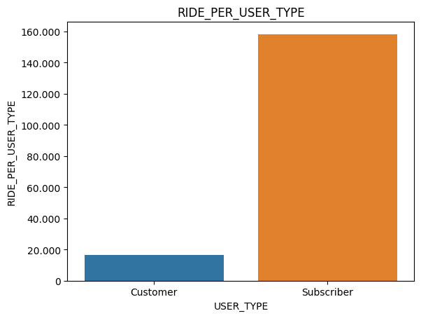

```python
#create a counterplot using seaborn package to understand how may rides are done by  subscribers or customers

sns.countplot(data = df_final, x = 'user_type')
plt.xlabel('USER_TYPE')
plt.ylabel('RIDE_PER_USER_TYPE')
plt.title('RIDE_PER_USER_TYPE')
plt.gca().yaxis.set_major_formatter(FuncFormatter(lambda x, _: f'{x:,.0f}'.replace(',', '.')))
;
```

```python
#clean the dabase and take just the rides under 1h of trip.

df_cleaned = df_final[df_final['duration_sec']<=3600]
df_cleaned
```

|  | duration_sec | start_time | end_time | bike_id | user_type | member_birth_year | member_gender | bike_share_for_all_trip | AGE | hour |
| --- | --- | --- | --- | --- | --- | --- | --- | --- | --- | --- |
| 4 | 1585 | 2019-02-28 23:54:18.549 | 2019-03-01 00:20:44.0740 | 4898 | Subscriber | 1974.0 | Male | Yes | 45.0 | 23 |
| 5 | 1793 | 2019-02-28 23:49:58.632 | 2019-03-01 00:19:51.7600 | 5200 | Subscriber | 1959.0 | Male | No | 60.0 | 23 |
| 6 | 1147 | 2019-02-28 23:55:35.104 | 2019-03-01 00:14:42.5880 | 3803 | Subscriber | 1983.0 | Female | No | 36.0 | 23 |
| 7 | 1615 | 2019-02-28 23:41:06.766 | 2019-03-01 00:08:02.7560 | 6329 | Subscriber | 1989.0 | Male | No | 30.0 | 23 |
| 8 | 1570 | 2019-02-28 23:41:48.790 | 2019-03-01 00:07:59.7150 | 6548 | Subscriber | 1988.0 | Other | No | 31.0 | 23 |
| ... | ... | ... | ... | ... | ... | ... | ... | ... | ... | ... |
| 183407 | 480 | 2019-02-01 00:04:49.724 | 2019-02-01 00:12:50.0340 | 4832 | Subscriber | 1996.0 | Male | No | 23.0 | 0 |
| 183408 | 313 | 2019-02-01 00:05:34.744 | 2019-02-01 00:10:48.5020 | 4960 | Subscriber | 1984.0 | Male | No | 35.0 | 0 |
| 183409 | 141 | 2019-02-01 00:06:05.549 | 2019-02-01 00:08:27.2200 | 3824 | Subscriber | 1990.0 | Male | Yes | 29.0 | 0 |
| 183410 | 139 | 2019-02-01 00:05:34.360 | 2019-02-01 00:07:54.2870 | 5095 | Subscriber | 1988.0 | Male | No | 31.0 | 0 |
| 183411 | 271 | 2019-02-01 00:00:20.636 | 2019-02-01 00:04:52.0580 | 1057 | Subscriber | 1989.0 | Male | No | 30.0 | 0 |

173374 rows × 10 columns

```python
#create the bins for the distribution. I decided to split the duration into bins of 10 minutes
bins = np.arange(0, df_cleaned['duration_sec'].max() + 600 ,  600 )
```

```
''
```

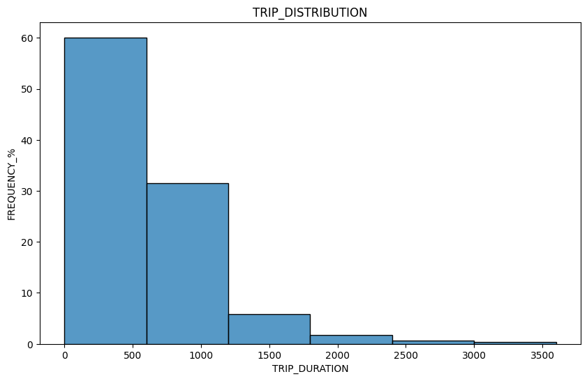

```python
#create a histogram using seaborn package to represent the distribution of the Bike_Trip
plt.figure(figsize=(10, 6))
sns.histplot(data = df_cleaned, x = 'duration_sec', bins= bins, stat = 'percent')
plt.xlabel('TRIP_DURATION')
plt.ylabel('FREQUENCY_%')
plt.title('TRIP_DISTRIBUTION')
;
```

> We can see some outlier points in duration of the trip. 1.3K rows out of 173K have a duration trips greater than 1H.. I had to remove this outlier to show the real distribution and plot the number in the correct way. i removed null values , take only the features needed for my analysis and only for the trip distribution , i had to subset the dataframe removing all the records greater than 1h of trip duration